# p8105_hw3_yl4613 codes

YuechenLiu

10/9/2020

### Problem 1

```r
data("instacart")
```

This dataset contains 1384617 and 15 columns.

Observations are the level of items in order by user. There are user / order variables – user ID, order ID, order day, and order hour. There are also item variables – name, aisle, department, and some numeric codes.

How many aisles, and which are most items from?

```r
instacart %>%
    count(aisle) %>%
    arrange(desc(n))
```

```
## # A tibble: 134 x 2
##    aisle                              n
##    <chr>                          <int>
##  1 fresh vegetables              150609
##  2 fresh fruits                  150473
##  3 packaged vegetables fruits     78493
##  4 yogurt                         55240
##  5 packaged cheese                41699
##  6 water seltzer sparkling water  36617
##  7 milk                           32644
##  8 chips pretzels                 31269
##  9 soy lactosefree                26240
## 10 bread                          23635
## # … with 124 more rows
```

Let’s make a plot

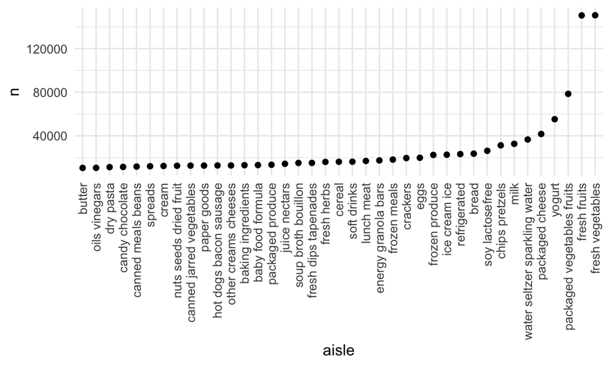

```r
instacart %>%
    count(aisle) %>%
    filter(n > 10000) %>%
    mutate(
        aisle = factor(aisle),
        aisle = fct_reorder(aisle, n)
    ) %>%
    ggplot(aes(x = aisle, y = n)) +
    geom_point() +
    theme(axis.text.x = element_text(angle = 90, vjust = 0.5, hjust = 1))
```

Let’s make a table!!

```r
instacart %>%
    filter(aisle %in% c("baking ingredients", "dog food care", "packaged vegetables fruits")) %>%
    group_by(aisle) %>%
    count(product_name) %>%
    mutate(rank = min_rank(desc(n))) %>%
    filter(rank < 4) %>%
    arrange(aisle, rank) %>%
    knitr::kable()
```

| aisle | product_name | n | rank |
| --- | --- | --- | --- |
| baking ingredients | Light Brown Sugar | 499 | 1 |
| baking ingredients | Pure Baking Soda | 387 | 2 |
| baking ingredients | Cane Sugar | 336 | 3 |
| dog food care | Snack Sticks Chicken & Rice Recipe Dog Treats | 30 | 1 |
| dog food care | Organix Chicken & Brown Rice Recipe | 28 | 2 |
| dog food care | Small Dog Biscuits | 26 | 3 |
| packaged vegetables fruits | Organic Baby Spinach | 9784 | 1 |
| packaged vegetables fruits | Organic Raspberries | 5546 | 2 |
| packaged vegetables fruits | Organic Blueberries | 4966 | 3 |

Apples vs ice cream..

```r
instacart %>%
    filter(product_name %in% c('Pink Lady Apples', 'Coffee Ice Cream')) %>%
    group_by(product_name, order_dow) %>%
    summarize(mean_hour = mean(order_hour_of_day)) %>%
    pivot_wider(
        names_from = order_dow,
        values_from = mean_hour
    )
```

```
## # A tibble: 2 x 8
## # Groups:   product_name [2]
##   product_name       `0`   `1`   `2`   `3`   `4`   `5`   `6`
##   <chr>            <dbl> <dbl> <dbl> <dbl> <dbl> <dbl> <dbl>
## 1 Coffee Ice Cream  13.8  14.3  15.4  15.3  15.2  12.3  13.8
## 2 Pink Lady Apples  13.4  11.4  11.7  14.2  11.6  12.8  11.9
```

### Problem 2

### load and tidy the data

```r
ac_data = read.csv(
    './accel_data.csv') %>%
    janitor::clean_names() %>%
    pivot_longer(activity_1:activity_1440,
                             names_to = 'minute_of_the_day',
                             values_to = 'activity_counts',
                             names_prefix = 'activity_') %>%
    mutate(
        type_of_day = case_when(
            day %in% c('Monday', 'Tuesday', 'Wednesday', 'Thursday', 'Friday') ~ 'weekday',
            day %in% c('Saturday', 'Sunday') ~ 'weekend'),
            day = as.factor(day),
        minute_of_the_day = as.integer(minute_of_the_day),
        type_of_day = as.factor(type_of_day))
```

The resulting data is tidier than the original dataset. It contains: number of the week (1-5), day_id(useless now so I left it alone), name of the data (Monday-Sunday), minute of the day (1-1440, every minute of a single day), activity_counts(the activity counts for each minute of that day), type_of_day(Monday-Friday are defined as weekdays, Saturday and Sunday are defined as weekends). There are 50400 observations in total, which contains 5 weeks, 35 days. So every day there are 1440 observations.

Traditional analyses–total activity of the day.

```r
sum_data =
    tibble(ac_data) %>%
    group_by(day, week) %>%
    summarize(activity_of_day = sum(activity_counts)) %>%
    relocate(week) %>%
    arrange(week) %>%
    pivot_wider(
        names_from = day,
        values_from = activity_of_day) %>%
    relocate(week, Sunday, Monday, Tuesday, Wednesday, Thursday, Friday, Saturday)
sum_data
```

```
## # A tibble: 5 x 8
##    week Sunday  Monday Tuesday Wednesday Thursday  Friday Saturday
##   <int>  <dbl>   <dbl>   <dbl>     <dbl>    <dbl>   <dbl>    <dbl>
## 1     1 631105  78828. 307094.   340115.  355924. 480543.   376254
## 2     2 422018 295431  423245    440962   474048  568839    607175
## 3     3 467052 685910  381507    468869   371230  467420    382928
## 4     4 260617 409450  319568    434460   340291  154049      1440
## 5     5 138421 389080  367824    445366   549658  620860      1440
```

Trends: The activity data during the middle of the week is more stable than that in weekends. For every week, week 1-3 have the most activities, whereas activities reduced during the last two weeks.

Plotting-24 hour activity

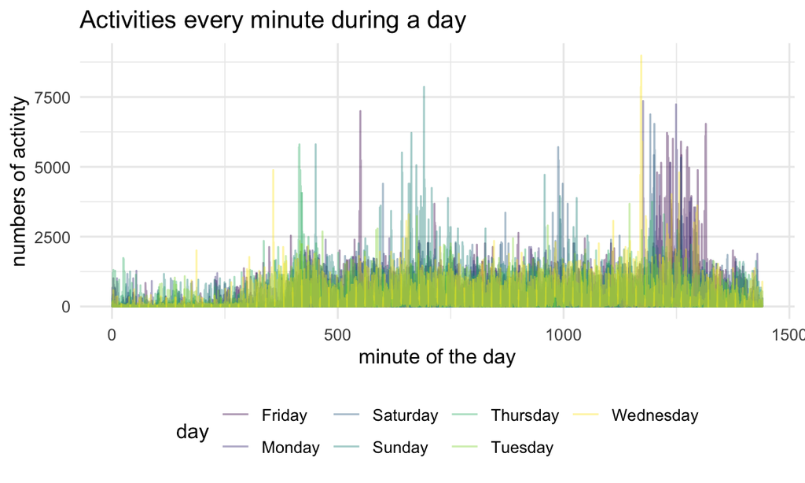

```r
ac_data %>%
    ggplot(aes(x = minute_of_the_day, y = activity_counts , color = day)) +
    geom_line(alpha = .4) +
    labs(x = 'minute of the day',
             y = 'numbers of activity',
             title = 'Activities every minute during a day')
```

From this plot, we can see that the activities during daytime are higher, and during the night are lower. It indicates that this patient has a daily routine that: wakes up ~7-8 am, have some activities before noon. He might take a nap / have some rest in the afternoon. He has high activity during ~8-11pm. And he sleeps usually after 11pm.

###Problem 3 ###load the data

```r
library(p8105.datasets)
data("ny_noaa")
```

Description: This dataset is about some weather-related parameters in NY these decades. These parameters include precipitation, snow fall, snow depth, maximum and minimum temperature. We have 2595176observations and 7 variables. As for the missing data, that of temperatures are very obvious in the 80’s and 90’s. After converting, temperature are in degree celsius, and data about snow/precipitation are in mm.

Data cleaning

```r
ny =
    ny_noaa %>%
    janitor::clean_names() %>%
    separate(date, c('year','month','day')) %>%
    mutate(
        prcp_mm = prcp / 10,
        snow_mm = as.numeric(snow),
        snwd_mm = as.numeric(snwd),
        tmax = as.numeric(tmax),
        tmax_C = tmax / 10,
        tmin = as.numeric(tmin),
        tmin_C = tmin / 10
        ) %>%
    select(-'prcp', -'snow', -'snwd', -'tmax', -'tmin')
ny %>%
    count(snow_mm) %>%
    arrange(desc(n))
```

```
## # A tibble: 282 x 2
##    snow_mm       n
##      <dbl>   <int>
##  1       0 2008508
##  2      NA  381221
##  3      25   31022
##  4      13   23095
##  5      51   18274
##  6      76   10173
##  7       8    9962
##  8       5    9748
##  9      38    9197
## 10       3    8790
## # … with 272 more rows
```

For snow fall, 0 is the most observed value. Because NY has no snow in most days of a year (even though it’s very cold).

Two-panel plot showing the average max temperature in January and in July in each station across years.

```r
Jan_Jul =
    ny %>%
    filter(month %in% c('01', '07')) %>%
    filter(!is.na(tmax_C)) %>%
    group_by(id, year, month) %>%
    summarize(
        avg_tmax = mean(tmax_C)
    )
```

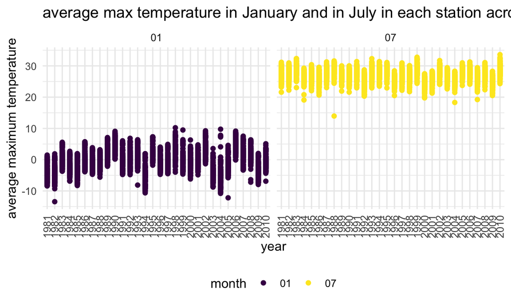

```r
Jan_Jul %>%
    ggplot(aes(x = year, y = avg_tmax, color = month, group = id))+
    geom_point()+
    labs(y = 'average maximum temperature',
             title = 'average max temperature in January and in July in each station across years')+
    facet_grid(. ~ month)+
    theme(axis.text.x = element_text(angle = 90, vjust = 0.5, hjust=1))
```

Make a two-panel plot showing (i) tmax vs tmin for the full dataset.

```r
max_min =
    ny %>%
    ggplot(aes(x = tmin_C, y = tmax_C))+
    geom_smooth()+
    labs(
        y = 'maximum temperature',
        x = 'minimum temperature',
        title = 'Max temp vs. Min temp'
    )
```

Comment: we can see that there is a huge difference in max vs min temperature in NY. There are extremely cold/ hot places, there are also mild-temperature places.

Make a plot showing the distribution of snowfall values greater than 0 and less than 100 separately by year.

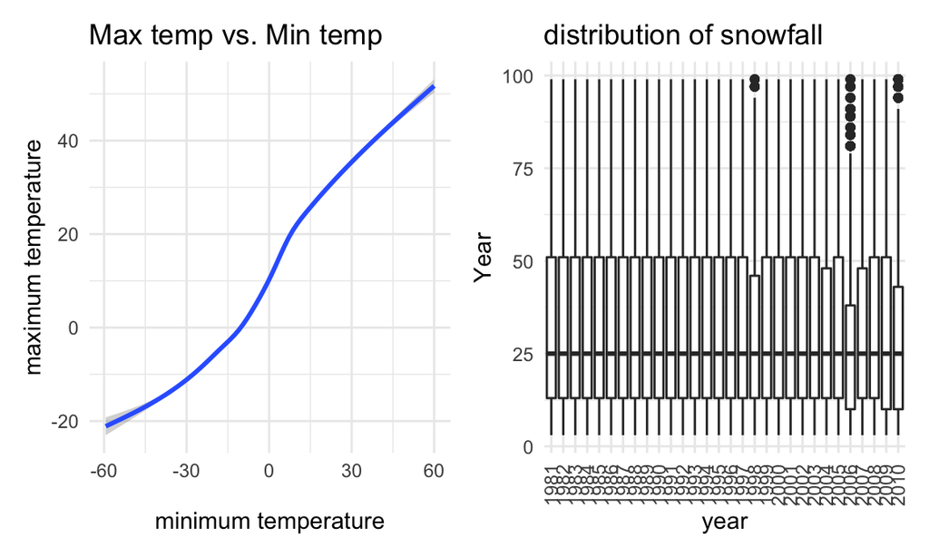

```r
snow_distribution =
    ny %>%
    filter(snow_mm > 0, snow_mm < 100) %>%
    ggplot(aes(x = year, y = snow_mm))+
    geom_boxplot()+
    labs(y = 'Year',
             y = 'Snowfall(mm)',
             title = 'distribution of snowfall')+
    theme(axis.text.x = element_text(angle = 90, vjust = 0.5, hjust=1))
(max_min) + (snow_distribution)
```

Comment: Distribution of snowfall were stable in the old days, but started to become a bit unstable from 1998. Then there were outliers in 2006 and 2010, more extreme snow distribution appeared in recent years.